# Tugas Pertemuan 2

Uiwang Nur Thoriq

2023-09-10

#Memanggil package yang dibutuhkan

```r
library(rio)
library(car)
library(lmtest) #Uji formal
library(orcutt) #Cochrane-Orcutt
library(HoRM) #Hildreth-Lu
```

#Import Data

Data yang digunakan adalah data qualitas air di New Delhi. Peubah respon yang digunakan adalah Air Quality Indeks atau Indeks Kualitas Udara, sedangkan peubah penjelasnya adalah kandungan CO, NO2, O3, SO2, PM10, dan PM25

```r
Datatugas2 <- import("https://raw.githubusercontent.com/UiwangNT/Praktikum_MPDW/main/pertemuan%202/data.csv")
Datatugas2
```

```
##     AQI       CO        NO2       O3      PM10     PM25       SO2
## 1  30.2 198.6027 0.04685717 55.78995 10.486722 5.637410 0.3874302
## 2  28.2 197.6013 0.04645554 54.93164 10.719325 4.618169 0.4097819
## 3  26.6 198.6027 0.04685717 54.64554 11.155578 3.520902 0.4023313
## 4  25.0 201.9405 0.04819594 55.07469 11.116206 2.225919 0.3762543
## 5  26.0 205.2784 0.04886533 55.78995 10.405250 1.979471 0.3390014
## 6  26.0 208.6163 0.05020411 56.50520  9.402518 1.792677 0.3129244
## 7  26.0 208.6163 0.05020411 55.78995  8.482822 1.752237 0.3129244
## 8  24.0 205.2784 0.05020411 52.92892  7.586667 1.858459 0.3427267
## 9  23.0 200.2716 0.04685717 50.06790  7.636587 2.208076 0.3948808
## 10 24.0 196.9338 0.04417961 51.49841  8.487648 2.476681 0.4284084
## 11 25.0 198.6027 0.04284084 53.64418  9.357371 2.585729 0.4284084
## 12 26.0 200.2716 0.04049798 55.78995 10.338728 2.390081 0.3986061
## 13 27.0 203.6095 0.04016329 59.36623 10.523314 2.086022 0.3501773
## 14 29.0 205.2784 0.03882451 62.22725 10.635970 1.937047 0.3166497
```

[output cut: 58 more lines]

#Eksplorasi Data Melakukan eksplorasi untuk melihat sebaran data masing-masing peubah penjelas dengan peubah respon.

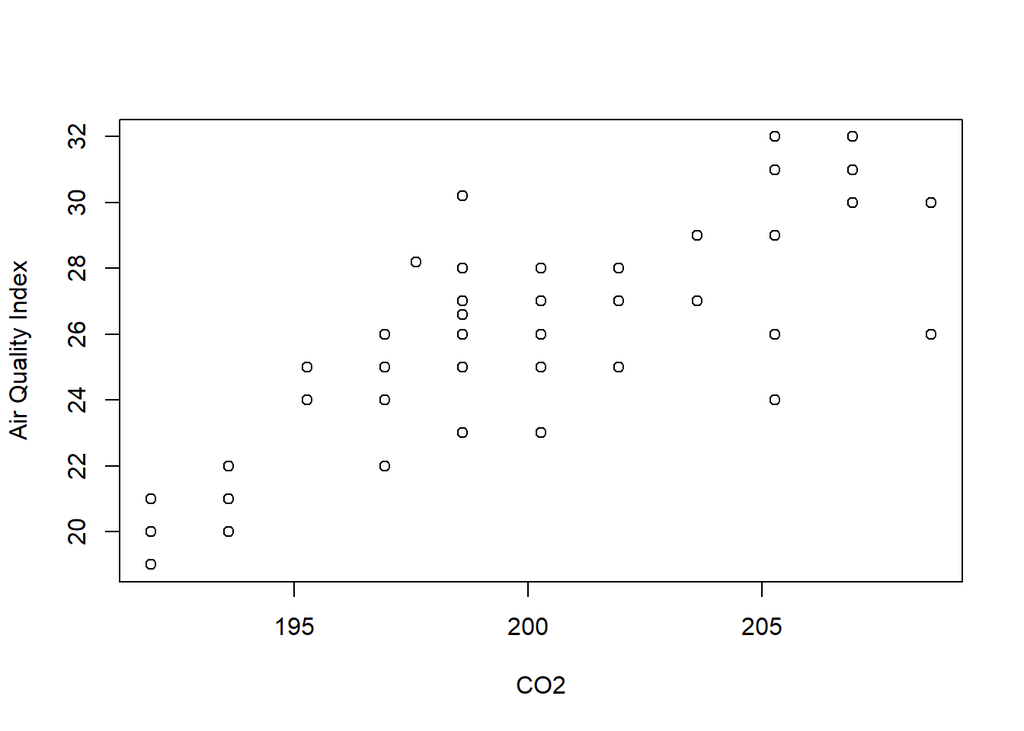

```r
plot(x=Datatugas2$CO, y=Datatugas2$AQI, xlab="CO2", ylab="Air Quality Index")
```

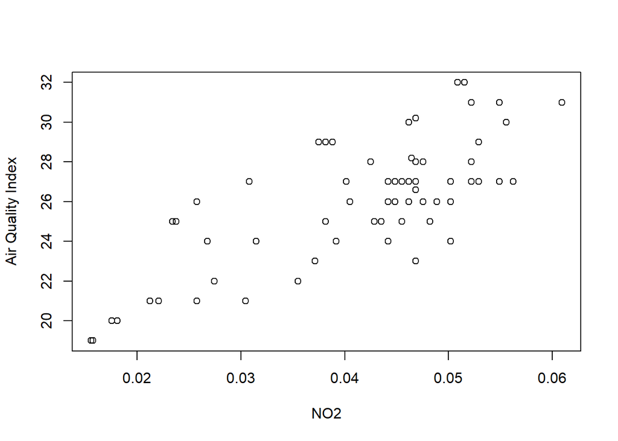

```r
plot(x=Datatugas2$NO2, y=Datatugas2$AQI, xlab="NO2", ylab="Air Quality Index")
```

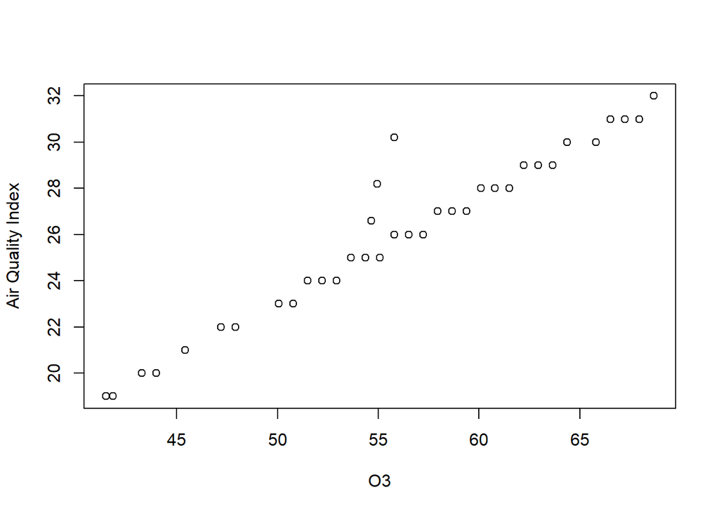

```r
plot(x=Datatugas2$O3, y=Datatugas2$AQI, xlab="O3", ylab="Air Quality Index")
```

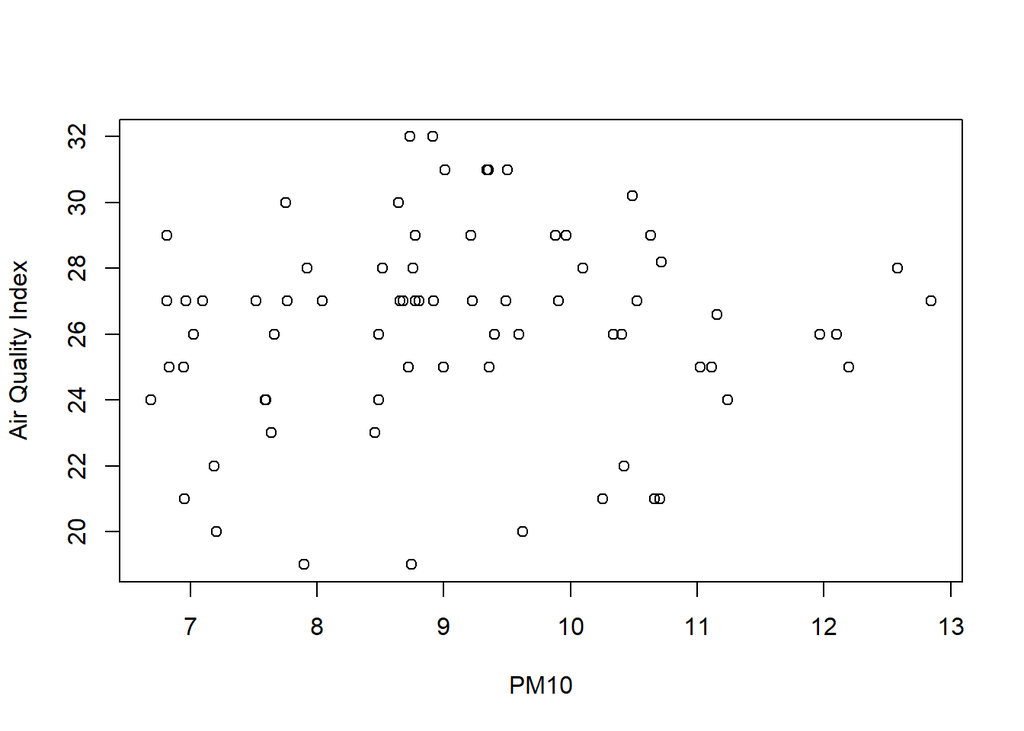

```r
plot(x=Datatugas2$PM10, y=Datatugas2$AQI, xlab="PM10", ylab="Air Quality Index")
```

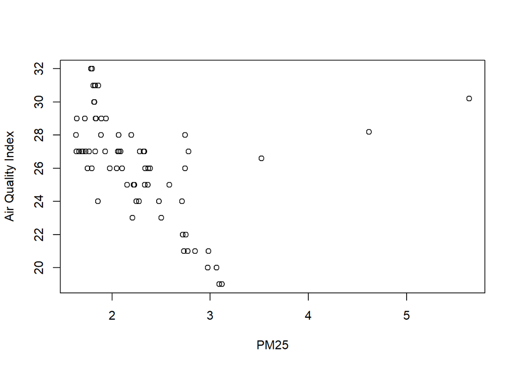

```r
plot(x=Datatugas2$PM25, y=Datatugas2$AQI, xlab="PM25", ylab="Air Quality Index")
```

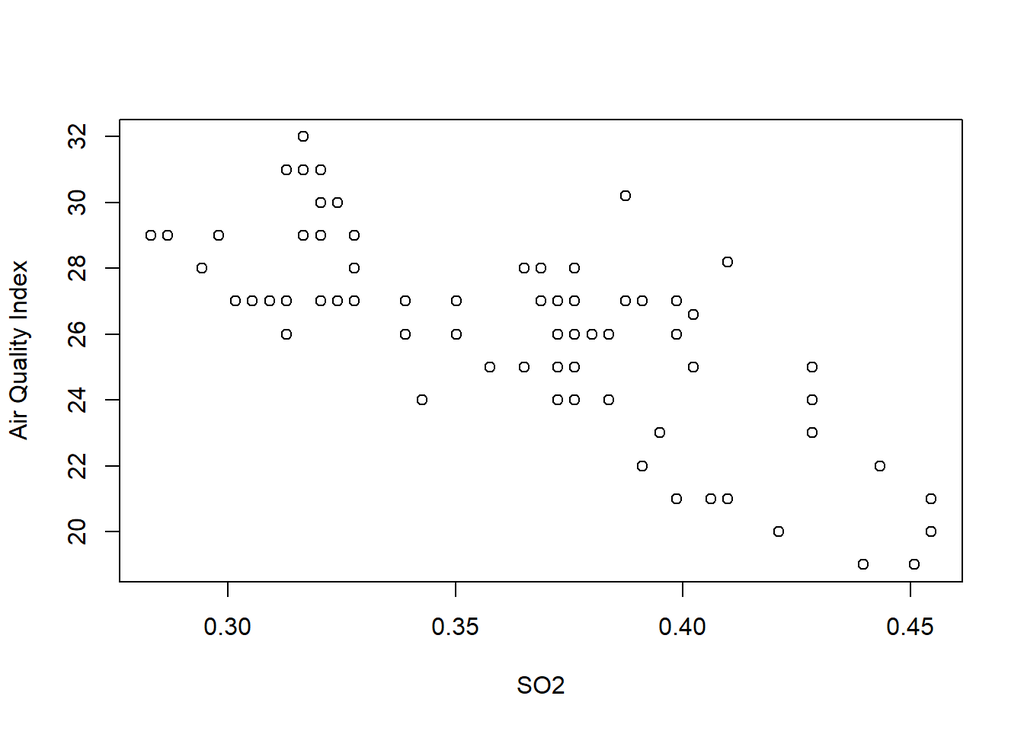

```r
plot(x=Datatugas2$SO2, y=Datatugas2$AQI, xlab="SO2", ylab="Air Quality Index")
```

Berdarkan beberapa plot antara peubah penjelas dan peubah respon, terlihat bahwa beberapa plot menunjukkan hubungan linear antara peubah penjelas dengan peubah respon.

#Regresi

```r
model<- lm(AQI~CO+NO2+O3+PM10+PM25+SO2,data=Datatugas2)
summary(model)
```

```
##
## Call:
## lm(formula = AQI ~ CO + NO2 + O3 + PM10 + PM25 + SO2, data = Datatugas2)
##
## Residuals:
##      Min       1Q   Median       3Q      Max
## -0.73339 -0.25673  0.03901  0.24063  0.52176
##
## Coefficients:
##             Estimate Std. Error t value Pr(>|t|)
## (Intercept) -1.46525    3.49796  -0.419  0.67668
## CO           0.01142    0.01674   0.682  0.49769
## NO2         16.32158    5.28647   3.087  0.00297 **
## O3           0.45725    0.01196  38.241  < 2e-16 ***
## PM10        -0.09697    0.02868  -3.381  0.00123 **
## PM25         1.36334    0.08151  16.726  < 2e-16 ***
## SO2         -9.45886    1.68392  -5.617 4.36e-07 ***
## ---
## Signif. codes:  0 '***' 0.001 '**' 0.01 '*' 0.05 '.' 0.1 ' ' 1
##
## Residual standard error: 0.3027 on 65 degrees of freedom
## Multiple R-squared:  0.991,  Adjusted R-squared:  0.9902
## F-statistic:  1194 on 6 and 65 DF,  p-value: < 2.2e-16
```

#Multikolinearitas

```r
vif(model)
```

```
##       CO      NO2       O3     PM10     PM25      SO2
## 4.429015 2.591475 4.582356 1.495781 2.218728 4.382814
```

Pada model tidak didapatkan adanya nilai VIF yang lebih besar dari 10, sehingga dapat disimpulkan bahwa tidak ada multikolinearitas antar peubah penjelas.

#Melihat asumsi secara eksploratif

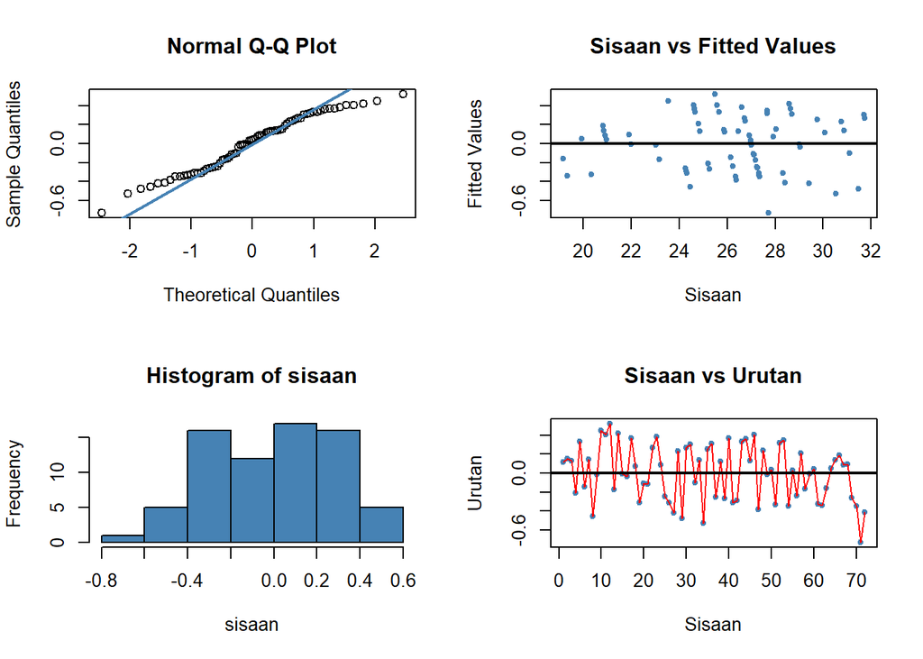

```r
sisaan<- residuals(model)
fitted<- predict(model)

#QQ-Plot
par(mfrow = c(2,2))
qqnorm(sisaan)
qqline(sisaan, col = "steelblue", lwd = 2)

#Plot Sisaan vs Fitted Value
plot(fitted, sisaan, col = "steelblue", pch = 20, xlab = "Sisaan", ylab = "Fitted Values", main = "Sisaan vs Fitted Values")
abline(a = 0, b = 0, lwd = 2)

#Histogram Sisaan
hist(sisaan, col = "steelblue")

#Plot Sisaan vs Urutan
plot(seq(1,nrow(Datatugas2),1), sisaan, col = "steelblue", pch = 20, xlab = "Sisaan", ylab = "Urutan", main = "Sisaan vs Urutan")
lines(seq(1,nrow(Datatugas2),1), sisaan, col = "red")
abline(a = 0, b = 0, lwd = 2)
```

QQ-plot menunjukkan bahwa sisaan menunjukkan pola yang simetris dengan ujung-ujung menebal. Pada histogram juga tidak menunjukkan bahwa sisaan cenderung menyebar normal. Pada plot Fitted Values vs Sisaan dan Sisaan vs Urutan menunjukkan tidak adanya pola pada sisaan, yang berarti tidak ada autokolerasi. Selanjutnya akan dilakukan pengujian asumsi dengan uji formaL, plot ACF dan PACF.

#Melihat sisaan menyebar normal atau tidak

```r
shapiro.test(sisaan)
```

```
##
##  Shapiro-Wilk normality test
##
## data:  sisaan
## W = 0.96636, p-value = 0.05099
```

```r
ks.test(sisaan, "pnorm", mean=mean(sisaan), sd=sd(sisaan))
```

```
##
##  Exact one-sample Kolmogorov-Smirnov test
##
## data:  sisaan
## D = 0.084463, p-value = 0.652
## alternative hypothesis: two-sided
```

Berdasarkan hasil uji yang dilakukan dengan uji Shapiro-Wilk dan Kolmogorov-Smirnov, didapatkan nilai p-value yang lebih besar dari 0,05 pada kedua uji. Maka dapat disimpulkan bahwa sisaan menyebar normal.

#Melihat adanya autokolerasi atau tidak

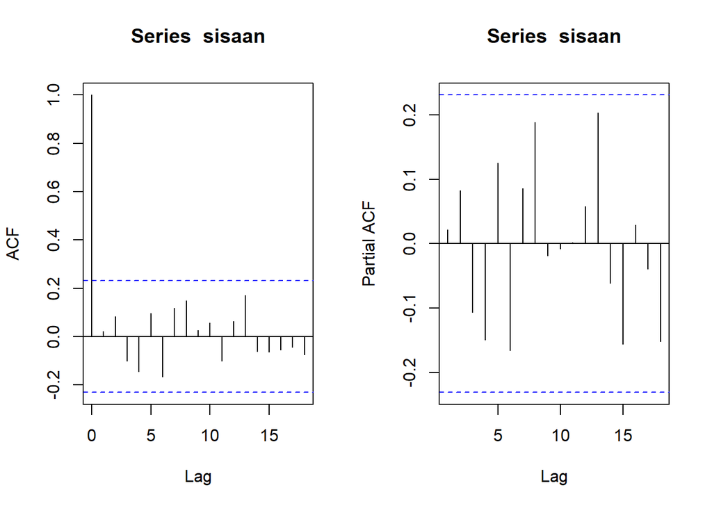

```r
#Plot ACF dan PACF
par(mfrow = c(1,2))
acf(sisaan)
pacf(sisaan)
```

```r
#Uji Durbin-Watson
dwtest(model)
```

```
##
##  Durbin-Watson test
##
## data:  model
## DW = 1.9256, p-value = 0.1541
## alternative hypothesis: true autocorrelation is greater than 0
```

Pada plot ACF dan PACF tidak terdeteksi adanya autokolerasi. Kemudian pada uji Durbin-Watson juga menunjukkan nilai p-value yang lebih besar dari 0,05. Maka dapat disimpulkan bahwa tidak terdapat autokolerasi pada sisaan.

Karena tidak ada autokolerasi pada sisaan, maka akan dilakukan pemodelan dengan beberapa peubah saja.

## Pemodelan dengan 4 peubah penjelas

# Pemodelan

```r
modelbaru<- lm(AQI~CO+O3+SO2+PM25,data=Datatugas2)
summary(modelbaru)
```

```
##
## Call:
## lm(formula = AQI ~ CO + O3 + SO2 + PM25, data = Datatugas2)
##
## Residuals:
##      Min       1Q   Median       3Q      Max
## -0.98991 -0.24307  0.07117  0.24172  0.56840
##
## Coefficients:
##             Estimate Std. Error t value Pr(>|t|)
## (Intercept) -6.95592    3.49162  -1.992   0.0504 .
## CO           0.03207    0.01735   1.848   0.0690 .
## O3           0.46975    0.01179  39.843  < 2e-16 ***
## SO2         -7.60068    1.73781  -4.374 4.37e-05 ***
## PM25         1.26645    0.08175  15.492  < 2e-16 ***
## ---
## Signif. codes:  0 '***' 0.001 '**' 0.01 '*' 0.05 '.' 0.1 ' ' 1
##
## Residual standard error: 0.3311 on 67 degrees of freedom
## Multiple R-squared:  0.9889, Adjusted R-squared:  0.9883
## F-statistic:  1494 on 4 and 67 DF,  p-value: < 2.2e-16
```

```r
vif(modelbaru)
```

```
##       CO       O3      SO2     PM25
## 3.976725 3.724877 3.902702 1.865888
```

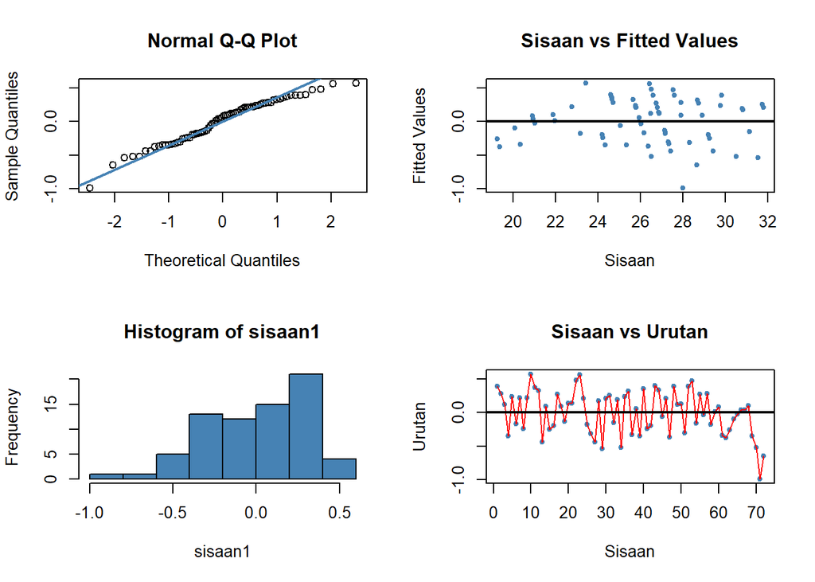

```r
sisaan1<- residuals(modelbaru)
fitted1<- predict(modelbaru)

#QQ-Plot
par(mfrow = c(2,2))
qqnorm(sisaan1)
qqline(sisaan1, col = "steelblue", lwd = 2)

#Plot Sisaan vs Fitted Value
plot(fitted1, sisaan1, col = "steelblue", pch = 20, xlab = "Sisaan", ylab = "Fitted Values", main = "Sisaan vs Fitted Values")
abline(a = 0, b = 0, lwd = 2)

#Histogram Sisaan
hist(sisaan1, col = "steelblue")

#Plot Sisaan vs Urutan
plot(seq(1,nrow(Datatugas2),1), sisaan1, col = "steelblue", pch = 20, xlab = "Sisaan", ylab = "Urutan", main = "Sisaan vs Urutan")
lines(seq(1,nrow(Datatugas2),1), sisaan1, col = "red")
abline(a = 0, b = 0, lwd = 2)
```

QQ-plot menunjukkan bahwa sisaan menunjukkan pola yang menyebar normal. Namun pada histogram tidak menunjukkan bahwa sisaan cenderung menyebar normal. Pada plot Fitted Values vs Sisaan dan Sisaan vs Urutan menunjukkan tidak adanya pola pada sisaan, yang berarti tidak ada autokolerasi. Selanjutnya akan dilakukan pengujian asumsi dengan uji formaL, plot ACF dan PACF.

#Uji Normalitas sisaan

```r
shapiro.test(sisaan1)
```

```
##
##  Shapiro-Wilk normality test
##
## data:  sisaan1
## W = 0.96767, p-value = 0.06071
```

```r
ks.test(sisaan1, "pnorm", mean=mean(sisaan1), sd=sd(sisaan1))
```

```
##
##  Exact one-sample Kolmogorov-Smirnov test
##
## data:  sisaan1
## D = 0.10607, p-value = 0.3668
## alternative hypothesis: two-sided
```

#Pendeteksian Autokolerasi

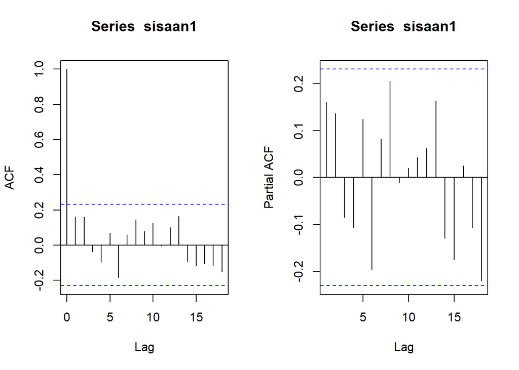

```r
#Plot ACF dan PACF
par(mfrow = c(1,2))
acf(sisaan1)
pacf(sisaan1)
```

```r
#Uji Durbin-Watson
dwtest(modelbaru)
```

```
##
##  Durbin-Watson test
##
## data:  modelbaru
## DW = 1.6017, p-value = 0.01489
## alternative hypothesis: true autocorrelation is greater than 0
```

Pada plot ACF dan PACF tidak terdeteksi adanya autokolerasi. Kemudian pada uji Durbin-Watson menunjukkan nilai p-value yang lebih kecil dari 0,05. Maka dapat disimpulkan bahwa terdapat autokolerasi pada sisaan.

#Penanganan dengan metode Cochrane Orcutt

```r
modelCO<-cochrane.orcutt(modelbaru)
modelCO
```

```
## Cochrane-orcutt estimation for first order autocorrelation
##
## Call:
## lm(formula = AQI ~ CO + O3 + SO2 + PM25, data = Datatugas2)
##
##  number of interaction: 13
##  rho 0.199496
##
## Durbin-Watson statistic
## (original):    1.60173 , p-value: 1.489e-02
## (transformed): 2.20360 , p-value: 6.609e-01
##
##  coefficients:
## (Intercept)          CO          O3         SO2        PM25
##   -4.379861    0.018310    0.472511   -5.847673    0.987641
```

```r
du<-1.7366
du
```

```
## [1] 1.7366
```

```r
batas<-4-du
batas
```

```
## [1] 2.2634
```

```r
rho<- modelCO$rho
rho
```

```
## [1] 0.1994957
```

Setelah dilakukan penanganan menggunakan Cochrane-orcutt, diperoleh nilai dw sebesar 2,2036 yang berada di antara 1,7366 dan 2,2634. Dari nilai dw tersebut dapat disimpulkan bahwa setelah melalui penanganan dengan Cochrane-orcutt, sudah tidak terdapat autokorelasi pada sisaan. Hal ini juga didukung dengan nilai p-value yang > 0,05. Diperoleh juga niai rho optimum sebesar 0,1994957.

#Transformasi Manual

```r
AQI<-Datatugas2$AQI
CO<-Datatugas2$CO
O3<-Datatugas2$O3
PM25<-Datatugas2$PM25
SO2<-Datatugas2$SO2

AQI.t<- AQI[-1]-AQI[-72]*rho
CO.t<- CO[-1]-CO[-72]*rho
O3.t<- O3[-1]-O3[-72]*rho
PM25.t<- PM25[-1]-PM25[-72]*rho
SO2.t<- SO2[-1]-SO2[-72]*rho
modelCOmanual<- lm(AQI.t ~ CO.t+O3.t+PM25.t+SO2.t)
summary(modelCOmanual)
```

```
##
## Call:
## lm(formula = AQI.t ~ CO.t + O3.t + PM25.t + SO2.t)
##
## Residuals:
##      Min       1Q   Median       3Q      Max
## -0.78832 -0.28230  0.04384  0.25020  0.58585
##
## Coefficients:
##             Estimate Std. Error t value Pr(>|t|)
## (Intercept) -3.50610    3.30048  -1.062   0.2920
## CO.t         0.01831    0.02044   0.896   0.3735
## O3.t         0.47251    0.01368  34.544  < 2e-16 ***
## PM25.t       0.98764    0.17184   5.747 2.52e-07 ***
## SO2.t       -5.84767    2.27191  -2.574   0.0123 *
## ---
## Signif. codes:  0 '***' 0.001 '**' 0.01 '*' 0.05 '.' 0.1 ' ' 1
##
## Residual standard error: 0.319 on 66 degrees of freedom
## Multiple R-squared:  0.9842, Adjusted R-squared:  0.9833
## F-statistic:  1030 on 4 and 66 DF,  p-value: < 2.2e-16
```

#Mencari Penduga Koefisien Regresi setelah Transformasi ke Persamaan Awal

```r
b0.bt <- modelCOmanual$coefficients[-c(2:5)]
b0 <- b0.bt/(1-rho)
b1 <- modelCOmanual$coefficients[-c(1,3:5)]
b2 <- modelCOmanual$coefficients[-c(1:2,4:5)]
b3 <- modelCOmanual$coefficients[-c(1:3,5)]
b4 <- modelCOmanual$coefficients[-c(1:4)]
b0
```

```
## (Intercept)
##   -4.379861
```

```r
b1
```

```
##       CO.t
## 0.01830966
```

```r
b2
```

```
##      O3.t
## 0.4725114
```

```r
b3
```

```
##    PM25.t
## 0.9876407
```

```r
b4
```

```
##     SO2.t
## -5.847673
```

Hasil yang diperoleh dari transformasi manual sama dengan hasil Cochrane orcutt menggunakan package.

# Penanganan dengan Metode Hildreth-Lu

```r
#Penanganan Autokorelasi Hildreth lu
# Hildreth-Lu
hildreth.lu.func<- function(r, model){
  x1 <- model.matrix(model)[,2]
  x2 <- model.matrix(model)[,3]
  x3 <- model.matrix(model)[,4]
  x4 <- model.matrix(model)[,5]
  y <- model.response(model.frame(model))
  n <- length(y)
  t <- 2:n
  y <- y[t]-r*y[t-1]
  x1 <- x1[t]-r*x1[t-1]
  x2 <- x2[t]-r*x2[t-1]
  x3 <- x3[t]-r*x3[t-1]
  x4 <- x4[t]-r*x4[t-1]

  return(lm(y~x1+x2+x3+x4))
}

#Pencariab rho yang meminimumkan SSE
r <- c(seq(0.1,0.9, by= 0.1))
tab <- data.frame("rho" = r, "SSE" = sapply(r, function(i){deviance(hildreth.lu.func(i, modelbaru))}))
round(tab, 4)
```

```
##   rho    SSE
## 1 0.1 6.7790
## 2 0.2 6.7168
## 3 0.3 6.7797
## 4 0.4 6.9707
## 5 0.5 7.3091
## 6 0.6 7.8042
## 7 0.7 8.3752
## 8 0.8 8.9602
## 9 0.9 9.6252
```

Nilai SSE minimum ketika rho bernilai 0,2. Selanjutnya akan dilakukan pencarian rho optimum dengan ketelitian yang lebih baik.

# Mencari Rho Optimal

```r
#Rho optimal
rOpt <- seq(0.1,0.3, by= 0.001)
tabOpt <- data.frame("rho" = rOpt, "SSE" = sapply(rOpt, function(i){deviance(hildreth.lu.func(i, modelbaru))}))
head(tabOpt[order(tabOpt$SSE),])
```

```
##       rho      SSE
## 100 0.199 6.716770
## 101 0.200 6.716771
## 99  0.198 6.716783
## 102 0.201 6.716783
## 98  0.197 6.716808
## 103 0.202 6.716808
```

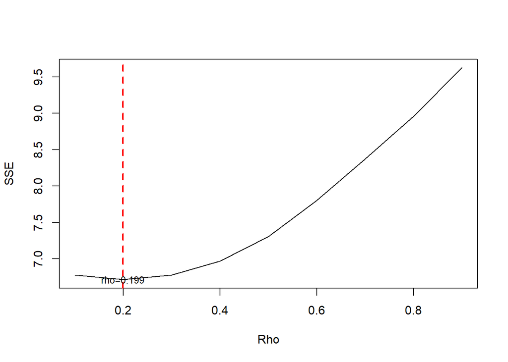

```r
#Grafik SSE
par(mfrow = c(1,1))
plot(tab$SSE ~ tab$rho , type = "l", xlab = "Rho", ylab = "SSE")
abline(v = tabOpt[tabOpt$SSE==min(tabOpt$SSE),"rho"], lty = 2, col="red",lwd=2)
text(x=0.199, y=6.716770, labels = "rho=0.199", cex = 0.8)
```

#Model Terbaik dengan Hidreth Lu

```r
modelHL <- hildreth.lu.func(0.199, modelbaru)
summary(modelHL)
```

```
##
## Call:
## lm(formula = y ~ x1 + x2 + x3 + x4)
##
## Residuals:
##      Min       1Q   Median       3Q      Max
## -0.78863 -0.28236  0.04387  0.25028  0.58604
##
## Coefficients:
##             Estimate Std. Error t value Pr(>|t|)
## (Intercept) -3.51338    3.30079  -1.064   0.2910
## x1           0.01834    0.02043   0.898   0.3724
## x2           0.47250    0.01367  34.560  < 2e-16 ***
## x3          -5.84895    2.27052  -2.576   0.0122 *
## x4           0.98796    0.17168   5.755 2.45e-07 ***
## ---
## Signif. codes:  0 '***' 0.001 '**' 0.01 '*' 0.05 '.' 0.1 ' ' 1
##
## Residual standard error: 0.319 on 66 degrees of freedom
## Multiple R-squared:  0.9842, Adjusted R-squared:  0.9833
## F-statistic:  1031 on 4 and 66 DF,  p-value: < 2.2e-16
```

```r
#Transformasi Balik
cat("y = ", coef(modelHL)[1]/(1-0.199), "+", coef(modelHL)[2],"x1","+",coef(modelHL)[3],"x2",coef(modelHL)[4],"x3","+", coef(modelHL)[5],"x4", sep = "")
```

```
## y = -4.386236+0.01834287x1+0.4725026x2-5.84895x3+0.9879594x4
```

Setelah dilakukan transformasi kembali, didapatkan model seperti berikut: y = -4.386236+0.01834287x1+0.4725026x2-5.84895x3+0.9879594x4

# Deteksi Autokorelasi kembali

```r
dwtest(modelHL)
```

```
##
##  Durbin-Watson test
##
## data:  modelHL
## DW = 2.2024, p-value = 0.659
## alternative hypothesis: true autocorrelation is greater than 0
```

Penanganan autokorelasi dengan Hidreth Lu menghasilkan nilai p-value sebesar 0,659 yang lebih besar dari 0,05. Maka dapat disimmpulkan bahwa sudah tidak ada autokorelasi.

#Perbandingan

```r
sseModelawal <- anova(modelbaru)$`Sum Sq`[5]
sseModelCO <- anova(modelCOmanual)$`Sum Sq`[5]
sseModelHL <- anova(modelHL)$`Sum Sq`[5]
mseModelawal <- sseModelawal/length(AQI)
mseModelCO <- sseModelCO/length(AQI)
mseModelHL <- sseModelHL/length(AQI)
akurasi <- matrix(c(sseModelawal,sseModelCO,sseModelHL,
                    mseModelawal,mseModelCO,mseModelHL),nrow=2,ncol=3,byrow = T)
colnames(akurasi) <- c("Model Awal", "Model Cochrane-Orcutt", "Model Hildreth-Lu")
row.names(akurasi) <- c("SSE","MSE")
akurasi
```

```
##     Model Awal Model Cochrane-Orcutt Model Hildreth-Lu
## SSE  7.3431233            6.71676893        6.71677046
## MSE  0.1019878            0.09328846        0.09328848
```

Dari perbandingan akurasi didapatkan nilai SSE pada penanganan dengan Cochrane-Orcutt lebih kecil daripada SSE dengan Hidreth-Lu. Namun keduanya tidak berbeda jauh dan keduanya menghasilkan nilai SSE yang lebih kecil dari model awal.

#Simpulan Pada pemodelan peubah respon AQI dengan peubah penjelas CO,O3,SO2,dan PM25 terdeteksi adanya autokorelasi sehingga perlu penanganan untuk autokorelasi. Dari 2 penanganan yang dilakukan, SSE pada Cochrane-Orcutt lebih kecil daripada SSE dengan Hidreth-Lu. Namun keduanya tidak berbeda jauh dan keduanya menghasilkan nilai SSE yang lebih kecil dari pemodelan awal.